# HAAM Summer School 2026

Jazmín Ramos Madrigal

### Clustering analyses

Description of the content

**Contents:**

- Data
- Pseudohaploid calling
- Plink files
- Principal Component Analysis (PCA)
  - smartPCA + projection
  - EMU
- Multidimensional Scaling (MDS)
- Unsupervised ADMIXTURE clustering

#### Data

For this session, we will be working with data from Schroeder *et al.* 2019, published in PNAS <sup>1</sup>. The goal is to replicate some of the results from that paper and identify the main ancestries present in the Koszyce individuals.

We will start from a BAM containing data from one of the Koszyce individuals and merge it with a SNP dataset consisting of modern and ancient individuals from relevant populations.

Once the datasets have been merged, we will use two clustering approaches to investigate the ancestry of the Koszyce individuals: PCA and MDS, using smartPCA <sup>2</sup> and EMU <sup>3</sup>, and unsupervised admixture clustering, using ADMXIXURE <sup>4</sup>.

First, using the PCA and MDS approaches, we will replicate the PCA in Figure 2 of the Schroeder *et al.* 2019 paper:

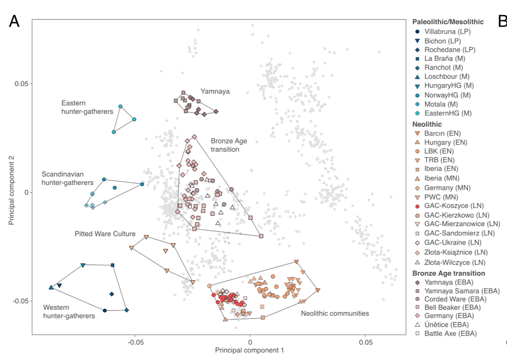

Figure 1. PCA from Schroeder et al. 2019 PNAS. Individuals in red are our tests individuals.

#### Pseudohaploid calling

**Start by setting up your working directory and environment**

First create a working directory for this session and activate the corresponding conda environment:

```bash
# activate the conda enviroment for the session:
conda activate unsupervised-analyses

# create a directory to work on the exercises:
clusteringDir="/home/ubuntu/unsupervised-analyses/"
mkdir -p $clusteringDir

cd $clusteringDir
```

Then download the data that you’ll need for this exercise:

```
# Download BAM file and other files that we will be using:
wget https://sid.erda.dk/share_redirect/F4jD8hhGdg/Data_MDS_PCA.tar.gz

# unzip the data
tar -xzvf Data_MDS_PCA.tar.gz

# go to the directory with the data:
cd Data_MDS_PCA

# Check that you can access the SNP dataset (otherwise see below how to download it)
ls /vol/volume/unsupervised-analyses/europe_haploid.*
```

##### PLINK files refresher

We will be working with `plink` <sup>5</sup> files, so just in case you are not familiar with them, here is a quick description.

PLINK files come in sets of 2 or 3 files and contain the genotype data, information about the SNP’s genomic coordinates, and information about the samples. Some common sets are TPED/TFAM, BED/BIM/FAM and MAP/PED files, all of which are interchangeable using `plink`. We will be working mostly with BED/BIM/FAM files, more information about the PLINK files and `plink` can be found [here](https://www.cog-genomics.org/plink/2.0/input).

The **BIM** file contains the information about the SNP’s genomic coordinates as well as the allele variants (one line per SNP):

```bash
# If you want to run this, make sure to specify the path to the plink files you just created:
head /vol/volume/unsupervised_analyses/Data_MDS_PCA/europe_haploid.bim
```

```
1       1_842013        0.62083 842013  G       T
1       1_891021        0.63933 891021  G       A
1       1_903426        0.66487 903426  T       C
1       1_949654        0.76002 949654  A       G
1       1_1018704       0.83152 1018704 A       G
1       1_1045331       0.87768 1045331 A       G
1       1_1048955       0.87872 1048955 G       A
1       1_1061166       0.88964 1061166 C       T
1       1_1108637       1.03627 1108637 A       G
1       1_1120431       1.13148 1120431 A       G
```

The **FAM** file contain information about the samples (one line per sample):

```bash
head /vol/volume/unsupervised_analyses/Data_MDS_PCA/europe_haploid.fam
```

```
0LS10 0LS10 0 0 0 1
0LS11 0LS11 0 0 0 1
3DT16 3DT16 0 0 0 1
3DT26 3DT26 0 0 0 1
6DT3 6DT3 0 0 0 1
6DT18 6DT18 0 0 0 1
6DT21 6DT21 0 0 0 1
6DT22 6DT22 0 0 0 1
6DT23 6DT23 0 0 0 1
12880A 12880A 0 0 0 1
```

The **BED** file is a compressed file that contains the genotype data.

```bash
head /vol/volume/unsupervised_analyses/Data_MDS_PCA/europe_haploid.bed
```

**Q:** How many SNPs and samples are present in this dataset? Consider the format of each of the files.

```bash
# You can check the number of samples by counting the lines of the FAM file:
wc -l /vol/volume/unsupervised_analyses/Data_MDS_PCA/europe_haploid.fam
2025
# and the number of SNPs by counting the lines in the BIM file:
wc -l /vol/volume/unsupervised_analyses/Data_MDS_PCA/europe_haploid.bim
442965
```

##### Pseudohaploid calling with ANGSD

For the pseudohaploid calling we will use `ANGSD -dohaplocall` to randomly sample one allele/read for each of the 442,965 SNPs in our dataset. More information about `ANGSD -dohaplocall` can be found [here](http://www.popgen.dk/angsd/index.php/Haploid_calling).

First we need to create a file with the sites that we want to extract from the BAM:

1. A list of chromosomes:

```bash
cut -f1 /vol/volume/unsupervised_analyses/Data_MDS_PCA/europe_haploid.bim |sort|uniq >chrs.txt
```

2. And list of positions and possible alleles (four columns: chromosome, position, allele1 and allele2):

```bash
cut -f 1,4,5,6 /vol/volume/unsupervised_analyses/Data_MDS_PCA/europe_haploid.bim > sites.txt
```

```bash
angsd sites index sites.txt
```

Now we can use `ANGSD -dohaplocall` to randomly sample a read per site from the BAM file of our ancient sample:

```bash
angsd -dohaplocall 1 -i /vol/volume/unsupervised_analyses/Data_MDS_PCA/Koszyce-3_6.bam -out Koszyce-3_6  -doCounts 1 -nThreads 1 -minMapQ 30 -minQ 20  -doMajorMinor 3 -sites sites.txt
```

What parameters are we using?

```
-i              the BAM file for our ancient sample
-out            the base name for the output
-doCounts 1     this parameter is necessary with dohaplocall
-nThreads 1     number of CPUs we want to use, 1 in this case
-minMapQ 30     minimum mapping quality for the reads (remember our BAM is not filterd yet)
-minQ 20        minimum base quality for the bases to be considered
-doMajorMinor 3 the option 3 takes into consideration the alleles present in the -sites file
-sites          the file containing the sites that are present in our reference dataset
```

Take a look at the output:

```bash
zcat Koszyce-3_6.haplo.gz |head
```

```
chr     pos     major   ind0
1       842013  T       T
1       903426  T       T
1       949654  G       G
1       1018704 A       A
1       1045331 G       G
1       1048955 A       A
1       1061166 C       C
1       1108637 G       G
1       1120431 G       G
```

**Q:** Did we recover all of the sites in the SNP dataset?

The next step is to transform `ANGSD` output into `PLINK` files (same format as our panel) so we can merge them with the reference SNP panel.

```bash
haploToPlink Koszyce-3_6.haplo.gz Koszyce-3_6_haplo
```

then, we can use `plink` to convert them into BED/BIM/FAM files:

```bash
plink --tfile Koszyce-3_6_haplo --make-bed --out Koszyce-3_6_haplo
```

Take a look at the parameters we are using with `plink`:

[output not shown]

Next, we want to edit the FAM file so that it has a meaningful name (this is optional, but it could help us to later identify the sample(s)).

Currently the FAM file looks like this:

```bash
cat Koszyce-3_6_haplo.fam
```

```
ind0 ind0 0 0 0 -9
```

We will change ind0 (`ANGSD` default name) for “Koszyce-3_6” and the -9 at the end for a 1:

```bash
echo "Koszyce-3_6 Koszyce-3_6 0 0 0 1" > Koszyce-3_6_haplo.fam
```

Now we can merge the two files with `plink`:

```bash
plink --bfile /vol/volume/unsupervised_analyses/Data_MDS_PCA/europe_haploid --make-bed --bmerge Koszyce-3_6_haplo --allow-no-sex --out  europe_haploid_k
```

**Q:** Did you get an **ERROR** message? Take a look at what the message says. Why do you think we have triallelic sites?

`plink` created a file that contains the SNPs where our ancient sample carries an allele different to the two alleles in the reference dataset:

```bash
head europe_haploid_k-merge.missnp
```

```
10_103284996
10_106551929
10_112471410
10_116534473
10_122499700
10_12392359
10_130541923
10_130948496
10_131298679
10_131719515
```

**Q:** Why do you think this is happening? How many sites are different?

```bash
wc -l europe_haploid_k-merge.missnp
```

We have to remove these sites from the BED/BIM/FAM files of our ancient sample before merging using `plink`:

```bash
plink --bfile Koszyce-3_6_haplo  --make-bed --allow-extra-chr --exclude europe_haploid_k-merge.missnp --allow-no-sex --out Koszyce-3_6_haplo_notri
```

[output not shown]

Now let’s try to merge the two files with `plink` again:

```bash
plink --bfile /vol/volume/unsupervised_analyses/Data_MDS_PCA/europe_haploid --make-bed --bmerge Koszyce-3_6_haplo_notri --allow-no-sex --out  europe_haploid_k
```

Finally, we have a new SNP dataset with both the Koszyce and reference data:

```bash
ls europe_haploid_k*
```

```
europe_haploid_k.bed
europe_haploid_k.bim
europe_haploid_k.fam
```

#### PCA with smartpca

We will estimate a PCA using our SNP dataset and `smartpca`.

**Note**: `convertf` and `smartpca` require that the samples names are shorter than 39/2 characters, so if you ever get an error saying: *idnames too long*, just change the names in the FAM file for a shorter version. We have some of these cases in our PLINK files, so we will edit the FAM file like this:

```bash
paste <(cut -d " " -f 2 europe_haploid_k.fam) <(cut -d " " -f 2-6 europe_haploid_k.fam) | perl -pe 's/SephardiJewTurkey/SJTurkey/g;' |perl -pe 's/Carsington_pasture/Cpasture/g;' > europe_haploid_k.newnames.fam
```

To convert the PLINK files into EIGENSTRAT we need to create a parameters file that contains the following:

```bash
echo 'genotypename: europe_haploid_k.bed
snpname: europe_haploid_k.bim
indivname: europe_haploid_k.newnames.fam
outputformat: EIGENSTRAT
genotypeoutname: europe_haploid_k.eigenstratgeno
snpoutname: europe_haploid_k.snp
indivoutname: europe_haploid_k.ind
familynames: YES
pordercheck: NO' > convertpanel.par
```

Now let’s use `convertf` to create our EIGENSTRAT files:

```bash
convertf -p convertpanel.par
```

**Q:** If you want, you can check how the EIGENSTRAT format looks like below:

You’ll have three files that contain information about the genotypes:

```bash
# SNP data
head  europe_haploid_k.eigenstratgeno
```

```
22900900029000022009000099000090099000900009009000
00000900000000000000000002000000000000000009200299
00200902029000029029000900000002000002000009000090
00000900000000220000000000900020099000000009000099
00900000000000000000000020000000000000090000000090
00090000000000000000222000900900000000000029000000
00900090000000220000020000099000000220009209000009
20002222209020002202002000900000099000000020000290
00000000000000000000002020020202299220020209200002
00000000000000000000000022020202200220200209020209
```

information about the SNPs:

```bash
# SNPs info
head  europe_haploid_k.snp
```

```
            1_842013     1        0.006208          842013 G T
            1_891021     1        0.006393          891021 G A
            1_903426     1        0.006649          903426 T C
            1_949654     1        0.007600          949654 A G
           1_1018704     1        0.008315         1018704 A G
           1_1045331     1        0.008777         1045331 A G
           1_1048955     1        0.008787         1048955 G A
           1_1061166     1        0.008896         1061166 C T
           1_1108637     1        0.010363         1108637 A G
           1_1120431     1        0.011315         1120431 A G
```

and information about the individuals:

```bash
# individuals
head  europe_haploid_k.ind
```

```
0LS10:0LS10 U 0LS10
0LS11:0LS11 U 0LS11
3DT16:3DT16 U 3DT16
3DT26:3DT26 U 3DT26
6DT3:6DT3 U 6DT3
6DT18:6DT18 U 6DT18
6DT21:6DT21 U 6DT21
6DT22:6DT22 U 6DT22
6DT23:6DT23 U 6DT23
12880A:12880A U 12880A
```

We will now edit the `europe_haploid_k.ind` to add a column with the sample name: (Check if you can copy&paste the following code, otherwise run the `Rscript EditIndFile.R`)

```bash
R
a<-read.table("europe_haploid_k.ind")
p<-as.character(a[,1])
p<-unlist(lapply(strsplit(p, ":"), "[[", 1))
a[,3]<-p
write.table(a, file="europe_haploid_k.ind", sep=" ", quote=F, row.names=F, col.names=F)
q("no")
```

or;

```bash
Rscript /vol/volume/unsupervised_analyses/Data_MDS_PCA/EditIndFile.R
```

Finally, we will run `smartPCA`, for which we need a file with parameters that looks like this:

```bash
echo 'genotypename: europe_haploid_k.eigenstratgeno
snpname: europe_haploid_k.snp
indivname: europe_haploid_k.ind
evecoutname: europe_haploid_k_pca.evec
evaloutname: europe_haploid_k_pca.eval
familynames: YES
numoutevec: 4
numthreads: 1
pordercheck: NO
poplistname: /vol/volume/unsupervised_analyses/Data_MDS_PCA/ModernPCs.txt
outliermode: 2
lsqproject: YES
' > pca_project.par
```

We will project the ancient individuals on top of a PCA made with the modern ones, like in the Schroeder *et al.* paper.

And we can run `smartpca` like this:

```bash
smartpca -p pca_project.par
```

After it is done running, you should have two new files now:

```bash
ls europe_haploid_k_pca.e*
```

```
europe_haploid_k_pca.evec
europe_haploid_k_pca.eval
```

It it is taking too long to run, you can download the output files here:

```
wget https://sid.erda.dk/share_redirect/F4jD8hhGdg/europe_haploid_k_pca.evec
wget https://sid.erda.dk/share_redirect/F4jD8hhGdg/europe_haploid_k_pca.eval
```

The *.evec* file contains sample names, followed by the coordinates for the samples in the first 4 PCs (or the number o PCs you indicated in the parameters file):

```bash
head -n 5 europe_haploid_k_pca.evec |column -t
```

```
#eigvals:    3.785    2.259    1.783   1.666
0LS10:0LS10  -0.0444  -0.0277  0.0198  -0.0035  0LS10
0LS11:0LS11  -0.0533  -0.0183  0.0172  0.0013   0LS11
3DT16:3DT16  -0.0325  0.0010   0.0062  0.0011   3DT16
3DT26:3DT26  0.0396   0.0246   0.0012  -0.0018  3DT26
```

And the *.eval* file contains the variance explained in each of the PCs:

```bash
head -n 5 europe_haploid_k_pca.eval
```

```
    3.784535
    2.259336
    1.783397
    1.666299
    1.634072
```

Now let’s plot the results using an Rscript that should be in your directory like this:

```bash
cp /vol/volume/unsupervised_analyses/Data_MDS_PCA/ColoursInfo.txt .
Rscript /vol/volume/unsupervised_analyses/Data_MDS_PCA/plotPCA.R europe_haploid_k_pca pca_Eurasia_k.pdf
```

```bash
cat plotPCA.R
```

```
####################################
# Estimate an MDS plot

# Run like this:
# Rscript plotPCA.R <base name for the evec/eval files> <output PDF>

# read input file names
Args<-commandArgs(T)
bfile<-Args[1]
outfilePDF<-Args[2]

# load libraries
library(ggplot2)
library(ggrepel)

# read both eval and evec files
mat<-read.table(paste0(bfile, ".evec"), as.is=T)
evals<-as.numeric(readLines(paste0(bfile, ".eval")))
ids<-sapply(strsplit(mat[,1], ":"), "[[", 2)

# return the to the original IDs:
ids<-gsub("SJTurkey", "SephardiJewTurkey", ids)
ids<-gsub("Cpasture", "Carsington_pasture", ids)
# read annotation file (should be in the same directory):

info<-read.table("ColoursInfo.txt", as.is=T, h=T, sep="\t")

# get the group name for each of the individuals:
groupAge<-NULL
colores<-NULL
relleno<-NULL
for(i in 1:length(ids)){
    if(sum(info$Sample==ids[i])>0){
        groupAge<-c(groupAge, info$groupAge[info$Sample==ids[i]])
        colores<-c(colores, info$color[info$Sample==ids[i]])
        relleno <-c(relleno, info$fill[info$Sample==ids[i]])
    }else{
        #message(ids[i])
        groupAge<-c(groupAge, "Ancient")
        colores<-c(colores, "black")
```

[output cut: 10 more lines]

```
pdf(outfilePDF, width=8.5, height=7, useDingbats=F)
ggplot(pcares, aes(x=pc1, y=pc2))+
geom_vline(xintercept=0, colour="gray", linetype = "longdash")+
geom_hline(yintercept=0, colour="gray", linetype = "longdash")+
geom_point(aes(pch=groupAge), colour=pcares$col, fill=pcares$fill, size=2, alpha=0.65, show.legend = TRUE)+
geom_point(data=pcares[grep("Koszyce",pcares$Sample), ], aes(pch=groupAge), colour="black", fill="black", size=2, alpha=0.65, show.legend = F)+
geom_text_repel(data=pcares[grep("Koszyce",pcares$Sample), ], aes(x=pc1, y=pc2, label=Sample), segment.size=0.1, segment.color="black", size=2, box.padding=unit(0.01, 'npc', ), max.overlaps=100)+
scale_shape_manual(values=Pchs)+
xlab(paste0("PC1 (", round(as.numeric(evals[1]), 2), "%)"))+
ylab(paste0("PC2 (", round(as.numeric(evals[2]), 2), "%)"))+
theme(panel.background = element_rect(fill='white', colour='black'), axis.text.x = element_text(colour='black'), axis.text.y = element_text(colour='black'), strip.background = element_rect(size=.2, colour="black", fill ="#FFA5004D"), panel.grid.major = element_blank(), panel.grid.minor = element_bla…

dev.off()

message("Done")
```

And once the script is done running, you’ll have a PCA like this:

The output should look like this:

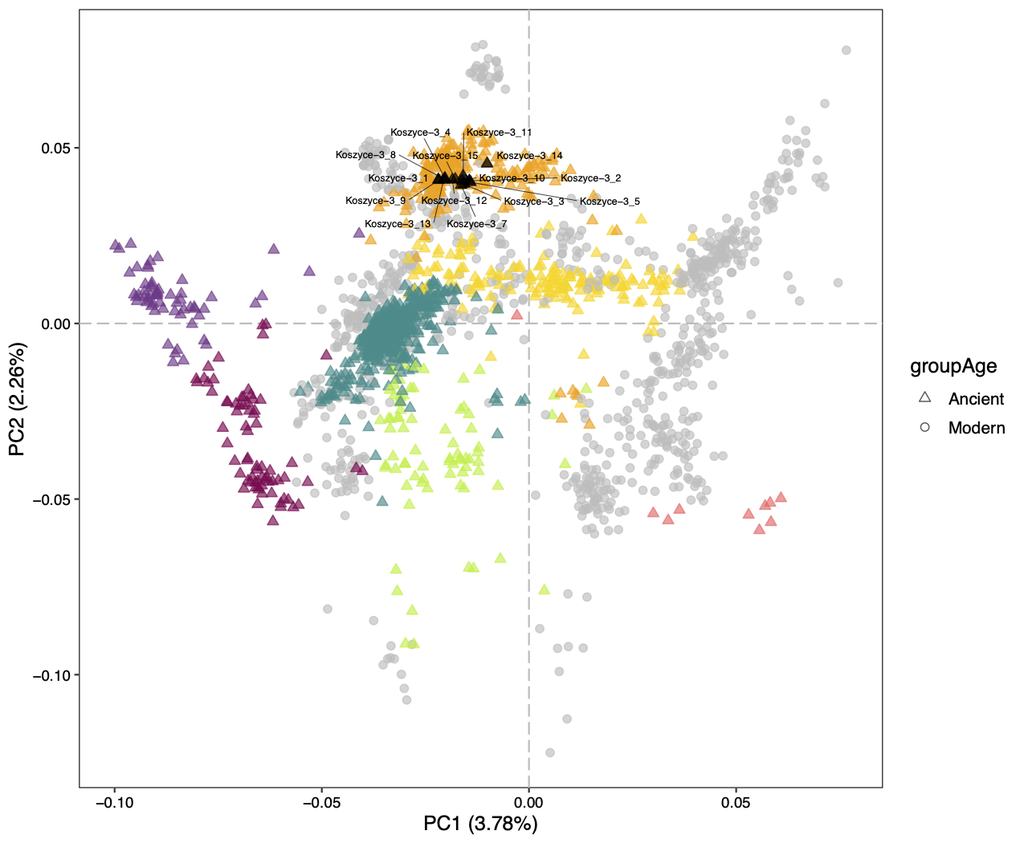

Figure 6. PCA projecting ancient samples.

Is this similar to the PCA from Schroeder *et al* 2019? What can we say about the Koszyce individuals?

#### MDS

Multidimensional scaling (MDS) is an alternative dimensionality reduction technique that is very easy to compute on genotype data. There are many ways to make an MDS plot, here is a simple way combining `plink` and `R`.

First, we need to estimate identity-by-state (IBS) pairwise-distances between all of our samples, so we will do that with the –distance-matrix option of plink. This opiton estimates pairwise IBS distances for all samples in a set of plink files:

```bash
plink --bfile europe_haploid_k --distance-matrix --out europe_haploid_k_dist
```

After, you get these two files:

```bash
ls europe_haploid_k_dist.*
```

```
europe_haploid_k_dist.mdist
europe_haploid_k_dist.mdist.id
```

Take a look at the file contents!

Then, we will use `cmdscale` function in `R` to get an MDS plot using the `plotMDS.R` script:

```bash
Rscript /vol/volume/unsupervised_analyses/Data_MDS_PCA/plotMDS.R europe_haploid_k_dist mds_eurasia_k.pdf
```

Take a look at what the script does:

```
####################################
# Estimate an MDS plot

# Run like this:
# Rscript plotMDS.R <base name for the IBS distance matrix> <output PDF>

# read input file names
Args<-commandArgs(T)
bfile<-Args[1]
outfilePDF<-Args[2]

# load libraries
library(ggplot2)
library(ggrepel)

# read both mdist and id files:
mat<-read.table(paste0(bfile, ".mdist"), as.is=T)
ids<-read.table(paste0(bfile, ".mdist.id"), as.is=T)[,1]

# read annotation file (should be in the same directory):
info<-read.table("ColoursInfo.txt", as.is=T, h=T, sep="\t")

# estimate an MDS using cmdscale:
m<-cmdscale(as.matrix(mat), k=(nrow(mat)-1), eig=TRUE, add=T)
nlambdas<-100*m$eig/sum(m$eig)

# parse the group name from the annotation file:
groupAge<-NULL
colores<-NULL
relleno<-NULL
for(i in 1:length(ids)){
    if(sum(info$Sample==ids[i])>0){
        groupAge<-c(groupAge, info$groupAge[info$Sample==ids[i]])
        colores<-c(colores, info$color[info$Sample==ids[i]])
        relleno <-c(relleno, info$fill[info$Sample==ids[i]])
    }else{
        #message(ids[i])
        groupAge<-c(groupAge, "Ancient")
        colores<-c(colores, "black")
        relleno <-c(relleno, "black")
```

[output cut: 11 more lines]

```

ggplot(mdsres, aes(x=dim1, y=dim2))+
geom_vline(xintercept=0, colour="gray", linetype = "longdash")+
geom_hline(yintercept=0, colour="gray", linetype = "longdash")+
geom_point(aes(pch=groupAge), colour=mdsres$col, fill=mdsres$fill, size=2, alpha=0.65, show.legend = TRUE)+
geom_point(data=mdsres[grep("Koszyce", mdsres$Sample), ], aes(pch=groupAge), colour="black", fill="black", size=2, alpha=0.65, show.legend = F)+
scale_shape_manual(values=Pchs)+
geom_text_repel(data=mdsres[grep("Koszyce", mdsres$Sample), ], aes(dim1, dim2, label=Sample), segment.size=0.1, segment.color="black", size=2, box.padding=unit(0.01, 'npc', ), max.overlaps=100)+
xlab(paste0("Dim1 (", round(as.numeric(nlambdas[1]), 2), "%)"))+
ylab(paste0("Dim2 (", round(as.numeric(nlambdas[2]), 2), "%)"))+
theme(panel.background = element_rect(fill='white', colour='black'), axis.text.x = element_text(colour='black'), axis.text.y = element_text(colour='black'), strip.background = element_rect(size=.2, colour="black", fill ="#FFA5004D"), panel.grid.major = element_blank(), panel.grid.minor = element_bla…

dev.off()

mesage("Done")
```

Once it is done running, you will have a plot that looks like this:

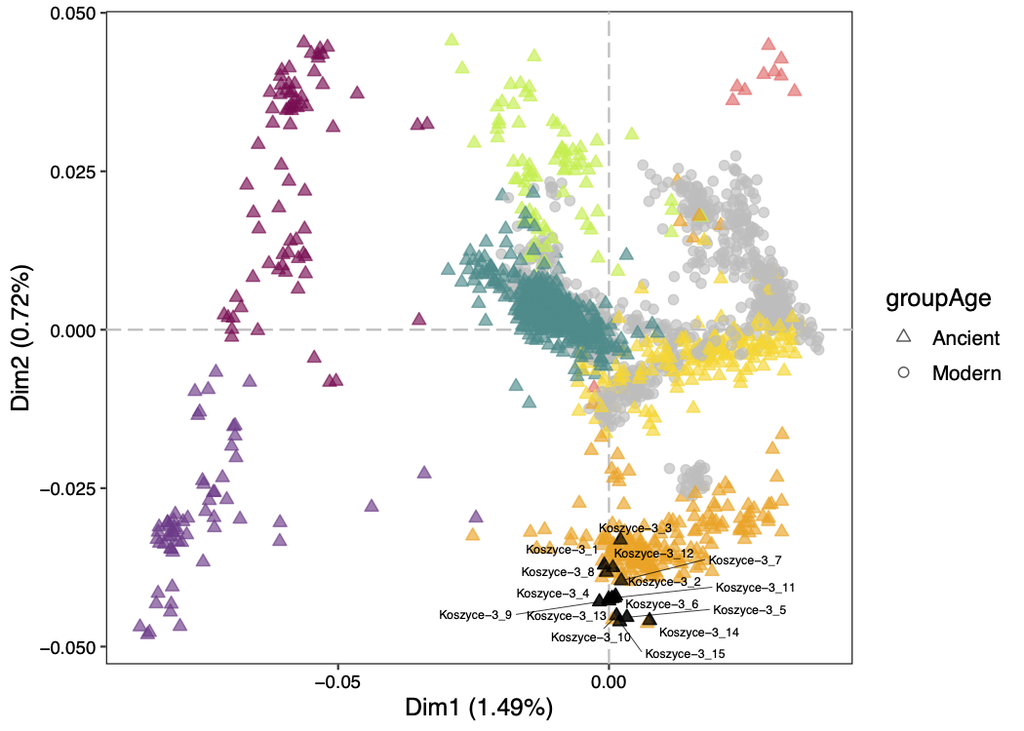

Multidimensional scaling plot. (right).

Is it similar to the PCA? What can we say about our test individuals?

#### PCA using EMU

Another way to do a PCA is EMU, which was specially developed for low-depth sequencing data with high missing rates. You can learn more about `EMU` [here](https://www.popgen.dk/software/index.php/EMU)

To facilitate that `EMU` converges, we will first apply a MAF filter on our pseudo-haploid dataset:

```bash
plink --bfile europe_haploid_k --maf 0.01 --geno 0.99 --make-bed --out europe_haploid_k_filtered
```

Then, we can run `EMU` like this:

```bash
emu -b europe_haploid_k_filtered -e 4 -t 1 -o  europe_haploid_k_filtered_emu
```

Now let’s plot the results:

```bash
Rscript /vol/volume/unsupervised_analyses/Data_MDS_PCA/plotEMU.R europe_haploid_k_filtered_emu europe_haploid_k_filtered pca_emu_eurasia_k.pdf
```

```bash
cat /vol/volume/unsupervised_analyses/Data_MDS_PCA/plotEMU.R
```

```
####################################
# Plot EMU PCA

# Run like this:
# Rscript plotEMU.R <base name of emu output> <basename of FAM file used to run EMU> <output PDF>

# read input file names
Args<-commandArgs(T)
bfile<-Args[1]
ffile<-Args[2]
outfilePDF<-Args[3]

# load libraries
library(ggplot2)
library(ggrepel)

# read input files:
mat<-read.table(paste0(bfile, ".eigvecs"), as.is=T)
evals<-as.numeric(readLines(paste0(bfile, ".eigvals")))
ids<-read.table(paste0(ffile, ".fam"), as.is=T)[,1]

# read annotation file (should be in the same directory):
info<-read.table("ColoursInfo.txt", as.is=T, h=T, sep="\t")

# parse the group name from the annotation file:
groupAge<-NULL
colores<-NULL
relleno<-NULL
for(i in 1:length(ids)){
    if(sum(info$Sample==ids[i])>0){
        groupAge<-c(groupAge, info$groupAge[info$Sample==ids[i]])
        colores<-c(colores, info$color[info$Sample==ids[i]])
        relleno <-c(relleno, info$fill[info$Sample==ids[i]])
    }else{
        #message(ids[i])
        groupAge<-c(groupAge, "Ancient")
        colores<-c(colores, "black")
        relleno <-c(relleno, "black")
    }
}
```

[output cut: 9 more lines]

```

ggplot(pcares, aes(x=pc1, y=pc2))+
geom_vline(xintercept=0, colour="gray", linetype = "longdash")+
geom_hline(yintercept=0, colour="gray", linetype = "longdash")+
geom_point(aes(pch=groupAge), colour=pcares$col, fill=pcares$fill, size=2, alpha=0.65, show.legend = TRUE)+
geom_point(data=pcares[grep("Koszyce", pcares$Sample), ], aes(pch=groupAge), colour="black", fill="black", size=2, alpha=0.65, show.legend = F)+
scale_shape_manual(values=Pchs)+
geom_text_repel(data=pcares[grep("Koszyce", pcares$Sample), ], aes(pc1, pc2, label=Sample), segment.size=0.1, segment.color="black", size=2, box.padding=unit(0.01, 'npc', ), max.overlaps=100)+
xlab(paste0("PC1 (", round(as.numeric(evals[1]), 2), "%)"))+
ylab(paste0("PC2 (", round(as.numeric(evals[2]), 2), "%)"))+
theme(panel.background = element_rect(fill='white', colour='black'), axis.text.x = element_text(colour='black'), axis.text.y = element_text(colour='black'), strip.background = element_rect(size=.2, colour="black", fill ="#FFA5004D"), panel.grid.major = element_blank(), panel.grid.minor = element_bla…

dev.off()

message("Done")
```

#### Clustering using ADMIXTURE

We will now use `ADMIXTURE` to estimate ancestry component and proportions.

First let’s download some data and scripts that we will need:

```
cd /vol/volume/unsupervised_analyses/
# Download the files that we will use:
wget https://sid.erda.dk/share_redirect/F4jD8hhGdg/Data_ADMIX.tar.gz

# Unzip the data:
tar -xzvf Data_ADMIX.tar.gz

# go to the folder with the data:
cd Data_ADMIX
```

An example of an `ADMIXTURE` run looks like this (don’t run it yet):

```
admixture -j1 --seed=$RANDOM day3_admx.bed 2 &> out.log
```

What parameters are we providing in this case?

```
-j1                     number of CPUs we want to use
-seed                   a starting seed, in this case $RANDOM is picking a random number
day3_admx.bed           our SNPs dataset
2                       the number of Ks or components into which we want to split our individuals
out.log                 a file to print the STDOUT
```

A peculiarity of `ADMIXTURE` is that it doesn’t allow you to specify the name of the output and instead the name is created from the name of the input file. Given we would like to run several replicates for each value of K we will need to create a directory for each `ADMIXTURE` run.

We will use the `runAdmxture.sh` script split our samples into 3 and 4 ancestry components (Ks) and run 5 replicates for each K:

Create a script to run ``ADMIXTURE`:

```bash
echo '# the first _for_ loop will determine the number of replicates
for rep in 1 2 3 4 5
do
 # make a directory for the current replicate
 mkdir $rep
 cd $rep
 # the second _for_ loop will determine the K
 for k in 3 4
 do
   admixture -j1 --seed=$RANDOM /vol/volume/unsupervised_analyses/Data_ADMIX/europe_haploid_k_admx.bed $k &> $rep"_"$k"_out.log"
 done
 cd ../
done
' > runAdmxture.sh
```

Now run the script:

```bash
bash runAdmxture.sh
```

It will take a few minutes to run.

**NOTE** If this is taking too long, you can download the files like this:

```bash
wget https://sid.erda.dk/share_redirect/F4jD8hhGdg/AdmixRes.tar.gz
tar -xzvf AdmixRes.tar.gz
```

**Q:** Do you remember why running replicates is important? How many parameters are we asking `ADMIXTURE` to estimate when we ask for K=3?

```bash
K=3
nSNPS=380621
nInds=76
TotalParms=(K*nSNPS)+(nIds*(K-1))
```

Now let’s check the results.

For each `ADMIXURE` run you will get three files, for example for replicate=1 and K=3:

```bash
ls -l 1/*3*
```

```
1/1_3_out.log
1/europe_haploid_k_admx.3.P
1/europe_haploid_k_admx.3.Q
```

You’ll have a *.P* file that contains the estimated allele frequencies for each site and for each of the 3 populations:

```bash
head 1/europe_haploid_k_admx.3.P
```

```
0.999990 0.741638 0.664138
0.881174 0.999990 0.999990
0.921161 0.686028 0.774169
0.999990 0.788439 0.999990
0.961652 0.999990 0.999990
0.880434 0.999990 0.887769
0.827978 0.825978 0.999990
0.876971 0.539222 0.472849
0.521588 0.999990 0.999990
0.540362 0.999990 0.999990
```

a *.Q* file that contains the estimated ancestry proportions of the 3 populations for each of the individuals:

```bash
head 1/europe_haploid_k_admx.3.Q
```

```
0.000010 0.548455 0.451535
0.000010 0.343791 0.656199
0.000010 0.999980 0.000010
0.000010 0.999980 0.000010
0.000010 0.000010 0.999980
0.000010 0.000010 0.999980
0.000010 0.999980 0.000010
0.000010 0.999980 0.000010
0.000010 0.999980 0.000010
0.000015 0.999975 0.000010
```

Check how many lines the .Q file has, is that expected?

```bash
wc -l 1/europe_haploid_k_admx.3.Q
```

How about the .P file?

```bash
wc -l 1/europe_haploid_k_admx.3.P
```

Finally, we have the log file which contains important information about the run:

```bash
cat 1/1_3_out.log
```

and at the end, there is a summary of the run:

```bash
tail -n 9 1/1_3_out.log
```

```
Summary:
Converged in 25 iterations (32.268 sec)
Loglikelihood: -3276680.135746
Fst divergences between estimated populations:
    Pop0    Pop1
Pop0
Pop1    0.273
Pop2    0.174   0.230
Writing output files.
```

In this case it says it converged after 25 iterations and the final Loglikelihood is -3276680.135746.

Now we need to decide which replicate is more likely to have reached a global maximum. Let’s check the *log* likelihood of all replicates for K=3:

```bash
grep "^Loglikelihood" */*_3_out.log
```

```
1/1_3_out.log:Loglikelihood: -3276680.135746
2/2_3_out.log:Loglikelihood: -3299675.887600
3/3_3_out.log:Loglikelihood: -3299676.076775
4/4_3_out.log:Loglikelihood: -3299675.888652
5/5_3_out.log:Loglikelihood: -3276680.271845
```

**How do we chose the replicate with the best likelihood?**

Remember that Likelihoods are the product of probabilities, therefore they become very small numbers very quickly.

It also means that the best model is one that has a higher likelihood (higher probabilities will produce a higher likelihood).

Because programming languages (and computers) are not good at dealing with numbers with a large number of digits, people normally work with *log* likelihoods.

Let’s plot the likelihood value vs. its log and see how it compares (**you don’t need to run this, since the plot is shown below!**):

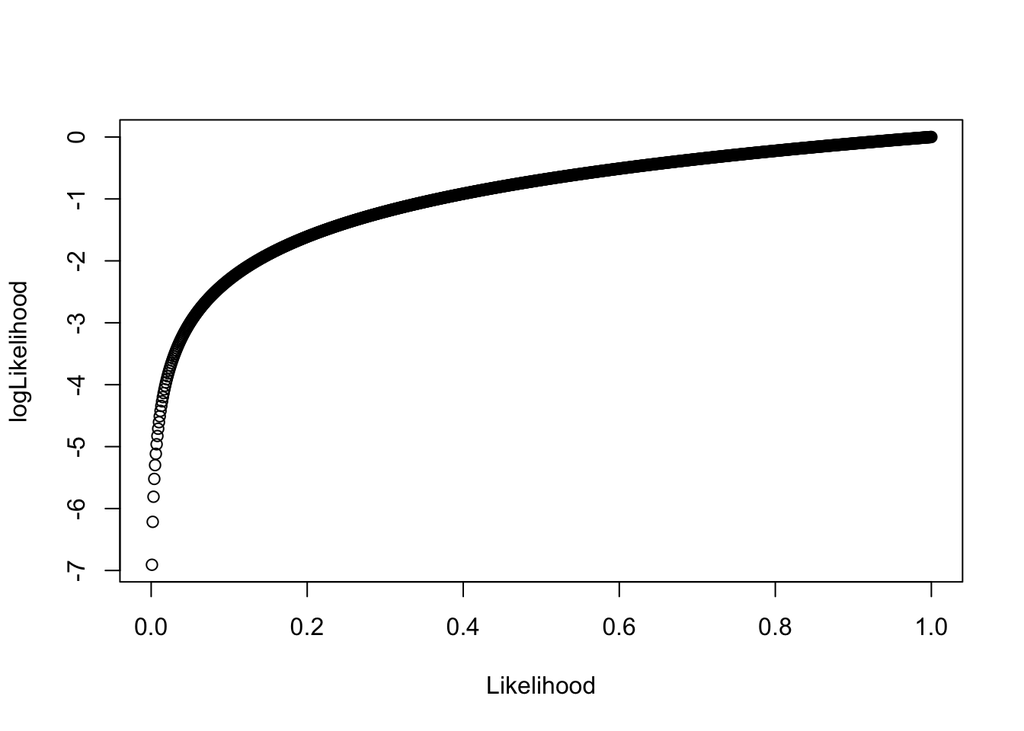

```r
# create a list of likelihoods:
Likelihood<-seq(0, 1, by=0.001)
# calculate the log likelihood:
logLikelihood<-log(Likelihood)

# Let's visualize the numbers
plot(Likelihood, logLikelihood)
```

As you can see, as the likelihood increases the *log* likelihood gets closer to 0.

**Note** that some programs instead of estimating the log likelihood, they estimate the *-log* likelihood, in which case you will have positive numbers.

**Q:** So, which replicate would you choose for each of the Ks?

Remember you can check all the likelihoods like this:

```bash
grep "^Loglikelihood" */*_3_out.log
```

```
1/1_3_out.log:Loglikelihood: -3276680.135746
2/2_3_out.log:Loglikelihood: -3299675.887600
3/3_3_out.log:Loglikelihood: -3299676.076775
4/4_3_out.log:Loglikelihood: -3299675.888652
5/5_3_out.log:Loglikelihood: -3276680.271845
```

```bash
grep "^Loglikelihood" */*_4_out.log
```

```
1/1_4_out.log:Loglikelihood: -3097801.389032
2/2_4_out.log:Loglikelihood: -3098449.925603
3/3_4_out.log:Loglikelihood: -3098449.931832
4/4_4_out.log:Loglikelihood: -3098472.597253
5/5_4_out.log:Loglikelihood: -3138790.755611
```

In the example above for admixture with K=3, the replicate with the best *log* likelihood is replicate 1 (-3276680.135746) and for K=4, the best one is also 1 (-3097801.389032)

Which one did you get?

Now, let’s plot all the replicates and see how they look:

(This is an option for plotting the results in R, but you can also check [$pong$](https://github.com/ramachandran-lab/pong), which is a very nice option to plot the results from `ADMIXTURE`)

```r
cp /vol/volume/unsupervised_analyses/Data_ADMIX/InfoAdmixture.txt .
cp /vol/volume/unsupervised_analyses/Data_ADMIX/admx_order_pops.txt .
cp /vol/volume/unsupervised_analyses/Data_ADMIX/europe_haploid_k_admx.fam .
# for K3
Rscript /vol/volume/unsupervised_analyses/Data_ADMIX/PlotAdmxReps.R europe_haploid_k_admx 3 europe_haploid_k_admx_k3.pdf
# for k4
Rscript /vol/volume/unsupervised_analyses/Data_ADMIX/PlotAdmxReps.R europe_haploid_k_admx 4 europe_haploid_k_admx_k4.pdf
```

```r
cat PlotAdmxReps.R
```

```
########################
# Rscript to plot all 5 replicates

# Run like this:
# Rscript PlotAdmxReps.R <basename plink files> <K> <outfile>

# read input file names
Args<-commandArgs(T)
bfile<-Args[1]
k<-Args[2]
outfilePDF<-Args[3]

# read metadata and fam files:
fam<-read.table(paste0(bfile, ".fam"), as.is=T)
info<-read.table("../MDS_PCA/day3.janno.txt", as.is=T, sep="\t", h=T, comment.char="")

# get the group name for each of the individuals:
Group_Name<-NULL
Country<-NULL
stype<-NULL
for(x in 1:length(fam[,1])){
        if(sum(info$Poseidon_ID==fam[x,2])>0){
                Group_Name <-c(Group_Name, info$Group_Name[info$Poseidon_ID==fam[x,2]])
                Country <-c(Country, info$Country[info$Poseidon_ID==fam[x,2]])
                stype <-c(stype, info$Date_Type[info$Poseidon_ID==fam[x,2]])
        }else{
                message(fam[x,2])
        }
}

# define order of individuals in the plot:
ucat<-readLines("admx_order_pops.txt")
ucat<-ucat[ucat %in% Group_Name]

o<-NULL
for(i in 1:length(ucat)){
    id<-which(Group_Name==ucat[i])
    o<-c(o, id)
    if(sum(Group_Name==ucat[i])==0){
        message(paste0("Error; ", i))
    }
}

# define colours for the admx components
cols<-list()
cols[[3]]<-c("deepskyblue", "gold", "indianred1")
cols[[4]]<-c("yellowgreen", "indianred1", "gold", "deepskyblue")

# plot the results
pdf(outfilePDF, height=8, width=12)
par(mar=c(0.5,3.5,0.5,0.5), mfrow=c(7,1))
for(i in 1:4){
    a<-t(read.table(paste0(i, "/", bfile, ".", k, ".Q"), as.is=T))
    barplot(a[,o], border=F, names=rep("", length(fam[o,2])), las=2, cex.names=1, col=cols[[k]])
}
i<-5
a<-t(read.table(paste0(i, "/", bfile, ".", k, ".Q"), as.is=T))
barplot(a[,o], border=F, names=paste0(Group_Name[o], ": ", fam[o,2]), las=2, cex.names=1, col=cols[[k]])
dev.off()
```

**Q:** Take a look at the five replicates for K=3, does the results vary?

Identify the replicate with the best log likelihood, is it different from the others?

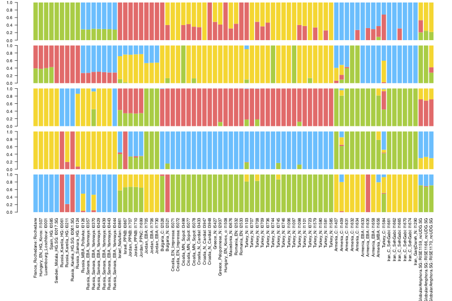

Figure. Admixture results using `ADMIXTURE` assuming 4 ancestry components (K=4).

What can we say about the ancestry of our test indiviuals?

**Estimating cross-validation errors for the best ADMIXTURE replicate** BONUS

One option to identify the K (number of clusters) that best explains your data is to perform a cross-validation (CV) for each K and identify the one with the smallest CV error.

The best way to do that is once you identified the *seed* that took you to the best likelihood for each replicate.

For example, we saw before that the replicate with the best likelihood for K=3 was replicate **1** (*log likelihood* = -3276680.135746):

```bash
grep "^Loglikelihood" */*_3_out.log
```

```
1/1_3_out.log:Loglikelihood: -3276680.135746
2/2_3_out.log:Loglikelihood: -3299675.887600
3/3_3_out.log:Loglikelihood: -3299676.076775
4/4_3_out.log:Loglikelihood: -3299675.888652
5/5_3_out.log:Loglikelihood: -3276680.271845
```

and the seed that took you to that loglikelihood is **2556**:

```bash
grep "Random seed:" 1/1_3_out.log
```

```
Random seed: 2556
```

We can do the same for K=4 and we would get the the replicate with the best *log likelihood* (-3097801.389032) is replicate **1** as well and the seed for that replicate was **32681**.

If we want to perform CV we can do that by re-running ADMIXTURE for each K starting at the seeds we identified. We won’t do that today, but you can check below how we could do that:

```
# Run cross-validation error for K=3
admixture -j2 --cv --seed=2556 europe_haploid_k_admx.bed 3 &> bestR_3_out.log

# and for K=4
admixture -j2 --cv --seed=32681 europe_haploid_k_admx.bed 4 &> bestR_4_out.log
```

Once this is done, you will have the cross-validation error in the $.log$ file:

```
grep CV bestR_*_out.log
```

```
bestR_3_out.log:CV error (K=3): 1.13248
bestR_4_out.log:CV error (K=4): 1.25416
```

Theoretically, the K that best explains your data will be the one with the smallest CV-error. Ideally, your CV-error would look like this:

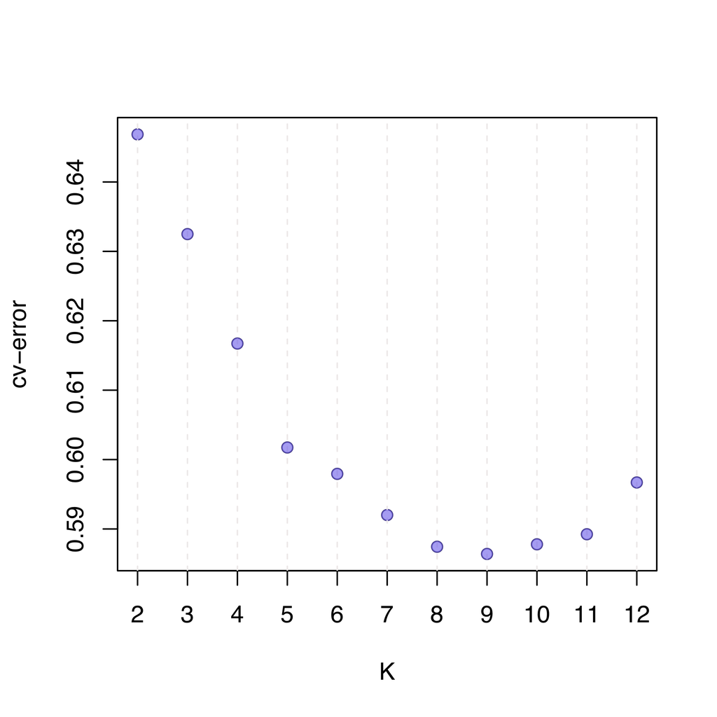

Figure 5. Example of a cross-validation error plot for K=2..12

In the example above, K=9 is the one that best fits the data.

### References

1. Schroeder H *et al.* 2019 **Unraveling ancestry, kinship, and violence in a Late Neolithic mass grave** PNAS. vol 116, no. 22, 10705–10710
2. Patterson, N *et al.* 2016. **Population Structure and Eigenanalysis**. PLoS genetics 2.12 e190.
3. Meisner J. *et al.* 2021. **Large-scale inference of population structure in presence of missingness using PCA** . Bioinformatics. Vol 37. Issue 13. Pag. 1868-1875.
4. Alexander, D. H, *et al.* 2009. **Fast Model-Based Estimation of Ancestry in Unrelated Individuals.** Genome Res. 19, 1655-1664.
5. Chang CC *et al.* 2015. **Second-Generation PLINK: Rising to the Challenge of Larger and Richer Datasets**. GigaScience, 4.
6. R Core Team. 2020. **R: A language and environment for statistical computing.** R Foundation for Statistical Computing, Vienna, Austria. URL: https://www.R-project.org/.
7. RStudio Team. 2019. **RStudio: Integrated Development Environment for R.** RStudio, Inc., Boston, MA. URL: http://www.rstudio.com/.